# examples_phys_units

```python
import numpy as np
import matplotlib.pyplot as plt

from glow import lenses, time_domain_c, freq_domain_c
from glow import physical_units as phys
```

## Automatic mode

### Basic

We can initalize both the lens object and the units object (to convert back to physical units) at the same time.

```python
# redshifts are mandatory for all lenses
zl = 1.5
zs = 3.

# all input quantities are regular floats (no astropy units)
p_lens = {'name':'CIS', 'Mvir_Msun':1e12, 'rc_pc':10}

Psi, units = phys.Lens_Units(zl, zs, p_lens)

print(Psi)
```

```
p_phys = {'name': 'CIS', 'psi0': 1.0, 'rc': 0.004923784057437897}
p_prec = {}
Psi = lenses.Psi_CIS(p_phys, p_prec)
```

Every lens expects different parameters. At the moment there is way to check what are these parameters, other than looking at the code or the documentation. Some other quantites are also computed along the way, and stored with `astropy` units in the object.

```python
display(units.d_eff)
display(units.Mlz)
display(units.Sigma_crit)
display(units.xi0)
display(units.Rvir)
```

$223.23263 \; \mathrm{Mpc}$

$9.6530522 \times 10^{10} \; \mathrm{M_{\odot}}$

$2979.7016 \; \mathrm{\frac{M_{\odot}}{pc^{2}}}$

$2030.9583 \; \mathrm{pc}$

$119.16169 \; \mathrm{kpc}$

If we have an array of dimensionless times we can convert them to physical units.

```python
taus = np.geomspace(1e-2, 1e1, 5)

ts = units.tau_to_t(taus)

display(taus)
display(ts)
```

```
array([ 0.01      ,  0.05623413,  0.31622777,  1.77827941, 10.        ])
```

$[19018.409,~106948.37,~601414.88,~3382004.4,~19018409] \; \mathrm{s}$

If we specify some units, we will get back a regular `numpy` array with these units, which can be easier to work with without needing to import `astropy`.

```python
ts = units.tau_to_t(taus, un='s')
ts
```

```
array([   19018.4085242 ,   106948.37052508,   601414.88408023,
        3382004.42902876, 19018408.52419662])
```

```python
ts = units.tau_to_t(taus, un='day')
ts
```

```
array([2.20120469e-01, 1.23782836e+00, 6.96082042e+00, 3.91435698e+01,
       2.20120469e+02])
```

Finally we can convert frequencies

```python
ws = np.geomspace(1e-2, 1e2, 4)

fs = units.w_to_f(ws)
fs
```

$[8.368468 \times 10^{-10},~1.8029318 \times 10^{-8},~3.8842988 \times 10^{-7},~8.368468 \times 10^{-6}] \; \mathrm{Hz}$

and distances

```python
xs = np.geomspace(1e-2, 1e2, 4)

xis = units.x_to_xi(xs)
xis
```

$[20.309583,~437.5567,~9426.8733,~203095.83] \; \mathrm{pc}$

The inverse operations are also implemented. Make sure that either 1) the input has astropy units or 2) you specify the units through the keyword. Example:

```python
taus = np.geomspace(1e-2, 1e1, 3)
print('Starting:   tau =', taus)

ts = units.tau_to_t(taus, un='hour')
print('t in hours: t   =', ts)

print('-'*30)
print('Revert the transformation:')

## ------------------------------------
taus1 = units.t_to_tau(ts, un='hour')

import astropy.units as u
taus2 = units.t_to_tau(ts*u.hour)
## ------------------------------------

print('  *    ok:  tau =', taus1)
print('  *    ok:  tau =', taus2)
```

```
Starting:   tau = [ 0.01        0.31622777 10.        ]
t in hours: t   = [   5.28289126  167.05969002 5282.89125672]
------------------------------
Revert the transformation:
  *    ok:  tau = [1.00000000e-02 3.16227766e-01 1.00000000e+01]
  *    ok:  tau = [1.00000000e-02 3.16227766e-01 1.00000000e+01]
```

### Different prescriptions

For some lenses we may want to use different unit conventions. We can add them as a new prescription in the `Units` object. For instance:

```python
zl = 1.3
zs = 3
p_lens = {'name':'NFW', 'Mvir_Msun':1e14}

Psi1, units1 = phys.Lens_Units(zl, zs, p_lens)
print(Psi1.p_phys)
print('')

Psi2, units2 = phys.Lens_Units(zl, zs, p_lens, prescription='radius')
print(Psi2.p_phys)
```

```
{'name': 'NFW', 'psi0': 1.0, 'xs': 1.243580960720822}

{'name': 'NFW', 'psi0': 0.6466240766893883, 'xs': 1.0}
```

In the first case, $\psi_0$ has been set to one, while in the second one we are using the scale radius as $\xi_0$. If we want to compare them directly, we must first use the same impact parameter

```python
# in the units system 1
y1 = 0.4

y_phys = units1.x_to_xi(y1)
y2 = units2.xi_to_x(y_phys)

y2
```

```
0.32165175620584147
```

and then switch to physical time.

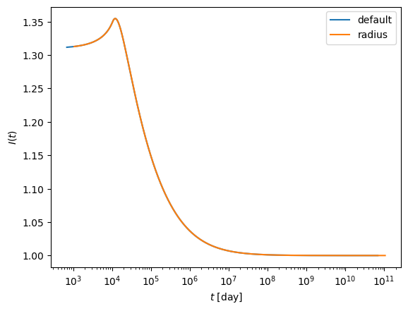

```python
It1 = time_domain_c.It_SingleIntegral_C(Psi1, y1)
It2 = time_domain_c.It_SingleIntegral_C(Psi2, y2)
## --------------------------------------------------

un = 'day'

t1 = units1.tau_to_t(It1.t_grid, un=un)
t2 = units2.tau_to_t(It2.t_grid, un=un)

fig, ax = plt.subplots()
ax.plot(t1, It1.It_grid/2/np.pi, label='default')
ax.plot(t2, It2.It_grid/2/np.pi, label='radius')

ax.set_xscale('log')
ax.set_xlabel('$t$ [%s]' % un)
ax.set_ylabel('$I(t)$')
ax.legend();
```

### Relating two lenses

We can also use an external unit convention. This is especially useful to relate different lenses.

```python
zl = 1.2
zs = 3.

p_lens1 = {'name':'CIS', 'Mvir_Msun':1e10, 'rc_pc':20}
p_lens2 = {'name':'SIS', 'Mvir_Msun':1e12}
```

We can use the first lens as reference for the second one

```python
Psi1, units = phys.Lens_Units(zl, zs, p_lens1)
Psi2, units = phys.Lens_Units(zl, zs, p_lens2, prescription='external', units_ext=units)

print(Psi1.p_phys)
print(Psi2.p_phys)
```

```
{'name': 'CIS', 'psi0': 1.0, 'rc': 0.18524045539212358}
{'name': 'SIS', 'psi0': 21.54434690031883}
```

or the other way around

```python
Psi2, units = phys.Lens_Units(zl, zs, p_lens2)
Psi1, units = phys.Lens_Units(zl, zs, p_lens1, prescription='external', units_ext=units)

print(Psi2.p_phys)
print(Psi1.p_phys)
```

```
{'name': 'SIS', 'psi0': 1.0}
{'name': 'CIS', 'psi0': 0.04641588833612781, 'rc': 0.008598100292814272}
```

### Composite lenses

We can also easily build composite lenses starting with their physical parameters.

```python
zl = 0.2
zs = 0.4

p0 = {'name':'point lens', 'M_Msun':2e2}
p1 = {'name':'off-center ball', 'M_Msun':34, 'R_Rsun':100, 'x1_pc':0.2,   'x2_pc':-0.45}
p2 = {'name':'off-center ball',       'M_Msun':8,  'R_Rsun':20,  'x1_pc':-0.15, 'x2_pc':-0.1}

p_lens = [p0, p1, p2]

Psi, units = phys.Lens_Units(zl, zs, p_lens)

for l in Psi.p_phys['lenses']:
    print(l.p_phys)
```

```
{'name': 'point lens', 'psi0': 1.0}
{'name': 'off-center ball', 'psi0': 0.16999999999999996, 'b': 1.998725030023698e-05, 'xc1': 1.77301164775328, 'xc2': -3.98927620744488}
{'name': 'off-center ball', 'psi0': 0.039999999999999994, 'b': 3.997450060047396e-06, 'xc1': -1.32975873581496, 'xc2': -0.88650582387664}
```

The first lens in the list will be used to set the units.

```python
p_lens = [p1, p0, p2]

Psi, units = phys.Lens_Units(zl, zs, p_lens)

for l in Psi.p_phys['lenses']:
    print(l.p_phys)
```

```
{'name': 'off-center ball', 'psi0': 1.0, 'b': 4.84762024432561e-05, 'xc1': 4.3001848818454045, 'xc2': -9.67541598415216}
{'name': 'point lens', 'psi0': 5.882352941176472}
{'name': 'off-center ball', 'psi0': 0.23529411764705888, 'b': 9.69524048865122e-06, 'xc1': -3.225138661384053, 'xc2': -2.1500924409227022}
```

## Manual mode

### Units from $M_{lz}$

It is possible to compute the conversion of units by directly specifying $M_{lz}$

```python
Mlz_Msun = 1e8

units = phys.Units_from_Mlz(Mlz_Msun)
```

Keep in mind that in this case we can convert times and frequencies, but nothing related to physical distances.

```python
taus = np.geomspace(1e-2, 1e2, 4)

ts = units.tau_to_t(taus)
ts
```

$[19.701964,~424.46594,~9144.8415,~197019.64] \; \mathrm{s}$

### Units only

If we know what we are doing, we can bypass initializing the lens and get only the units

```python
zl = 1.3
zs = 3

p_lens = {'name':'SIS', 'Mvir_Msun':1e10}

units = phys.Units(zl, zs, p_lens)
```

In many cases, this is enough since the actual computation in dimensionless can be reused for all the redshifts and masses.